# Get a Grip! When to Control for Variables in a Regression

```r
library(tidyverse)
library(glue)
```

https://pixabay.com/photos/mixer-dj-controller-buttons-4197733/

Linear regression models make it easy to measure the effect of a treatment holding other variables fixed. But when and why should these covariates be included?

This post will answer that question:

First, we’ll talk about covariates in the context of prediction: add controls when they improve out of sample fit.

Then, we’ll discuss when you should use controls to measure a causal effect and when you shouldn’t: Bias - Add confounders that influence the treatment and the outcome to reduce bias - Don’t add downstream effects of the treatment that also influence outcomes because you won’t measure the full impact of treatment - Don’t add colliders that are caused by both treatment and the outcome because you may end up inducing a spurious relationship between treatment and outcomes

Precision - Add controls that are predictive of outcomes, but not treatment to increase precision - Don’t add controls that are predicitve of treatment, but not outcomes

# Prediction: Out of Sample Performance

If you are not influencing the value of any of the variables in the regression, you might only care about prediction. For example, if you were looking to sell an apartment, you might want to predict the sale price. You could train a regression on the sale price of other apartments including covariates like the number of bedrooms. In this case, you probably only care about getting a good prediction of the sale price. You likely are not looking to evaluate if you added another bedroom, how much more could you sell for (which, by contrast would be a causal problem).

It is easy to decide whether or not a covariate should be added to a regression if all you care about is predicting an outcome. Simply separate your data into a training set and a test set. Train the model with the covariate and without using the training data. Whichever model does a better job predicting in the test data should be used.

Adding covariates reduces the bias in your predictions, but increases the variance. Out of sample fit is the judge of this tradeoff. If you have many variables, techniques like L1 regularization can help determine which to include.

Things get more complicated when you are trying to measure a causal effect.

# Causal Effects

Regressions are highly interpretable. It is easy to identify how the change of a variable in a regression is associated with a change in the outcome through the coefficients of the regression. For example, if you own a lot of grooming salons, you might consider whether or not you want to give dogs bandanas as they leave so they look cute. You want to know if giving bandanas will increase revenue so you run a regression:
$$Revenue_{salon} \sim \beta_0 + \beta_1gives\_bandanas_{salon}$$
Where gives_bandanas is a 0, 1 indicator variable whether or not the salon gives bandanas. _1 will exactly tell you the impact on revenue that is associated with giving bandanas.

The reasons for adding or not adding controls to a regression generally fall into two categories: 1- Getting the Measurement right (eg reducing bias) 2- Precision of effect measurement

## Getting the Measurment Right

### Add Confounders that Could Bias the Estimate

Confounders can make your treatment effect estimates incorrect if you don’t account for them. A confounder is something that influences (causes) the value of both the treatment (exposure) and the outcome.

*picture https://catalogofbias.org/biases/collider-bias/*

For example, let’s say customers in fancy neighborhoods are more inclined to request bandanas. Fancy neighborhoods also tend to have people that spend more money on dog grooms. Thus, fancy neighborhoods influence both the treatment (whether or not the salon gives bandanas) and the outcome (revenue) and is a confounder.

Let’s illustrate:

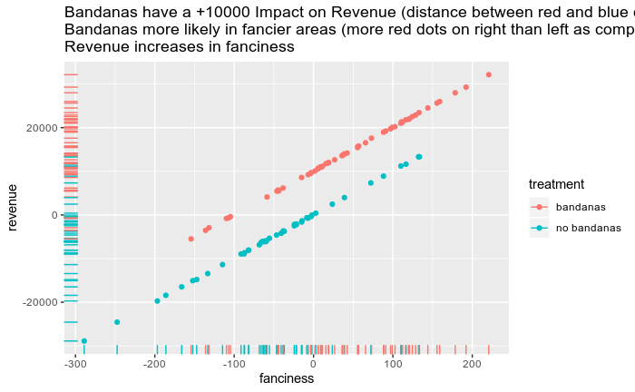

```r
# create a salon level dataset
set.seed(20)
n_salons <- 100
noise <- 100
true_bandana_effect <- 10000
data_confounder <- tibble(salon_id = 1:n_salons) %>%
  mutate(
    # confounder
    fanciness=rnorm(n_salons, sd = noise),
    # treatment (influenced by confounder)
    #   if fanciness > 0, chance of bandana = 1 is .8, else .2
    gives_bandanas=rbinom(n_salons, 1,prob =  ifelse(fanciness > 0, .8, .2)),
    # outcome (influenced by confounder and treatment),
    revenue=100*fanciness + true_bandana_effect*gives_bandanas + 50 + rnorm(n_salons, sd=noise)
  )

# plot to visualize the relationships
data_confounder %>%
  mutate(treatment=ifelse(gives_bandanas==1, "bandanas", "no bandanas")) %>%
  ggplot(aes(fanciness, revenue, color=treatment)) +
  geom_point() +
  labs(title=glue("Bandanas have a +{true_bandana_effect} Impact on Revenue (distance between red and blue curves)\n",
                  "Bandanas more likely in fancier areas (more red dots on right than left as compared to blue dots)\n",
                  "Revenue increases in fanciness")) +
  geom_rug()
```

Now let’s see what would happen if we don’t control for fanciness.

```r
summary(m)
```

```
Call:
lm(formula = revenue ~ gives_bandanas, data = data)

Residuals:
     Min       1Q   Median       3Q      Max
-24181.7  -4226.9   -195.1   5768.6  18096.4

Coefficients:
               Estimate Std. Error t value Pr(>|t|)
(Intercept)       -4702       1331  -3.533 0.000629 ***
gives_bandanas    18738       1795  10.440  < 2e-16 ***
---
Signif. codes:  0 ‘***’ 0.001 ‘**’ 0.01 ‘*’ 0.05 ‘.’ 0.1 ‘ ’ 1

Residual standard error: 8929 on 98 degrees of freedom
Multiple R-squared:  0.5266,    Adjusted R-squared:  0.5217
F-statistic:   109 on 1 and 98 DF,  p-value: < 2.2e-16
```

The true effect of gives_bandanas is a $10000 increase to revenue, but we measured a much larger effect. In fact, the true effect doesn’t even fall in our models 95% confidence interval for the effect. But what if we add fanciness to the regression?

```r
summary(m_controlled)
```

```
Call:
lm(formula = revenue ~ gives_bandanas + fanciness, data = data)

Residuals:
    Min      1Q  Median      3Q     Max
-243.13  -77.57    7.44   77.87  279.80

Coefficients:
                Estimate Std. Error t value Pr(>|t|)
(Intercept)      66.8213    17.4483    3.83 0.000228 ***
gives_bandanas 9977.9246    24.6659  404.52  < 2e-16 ***
fanciness       100.0536     0.1246  803.08  < 2e-16 ***
---
Signif. codes:  0 ‘***’ 0.001 ‘**’ 0.01 ‘*’ 0.05 ‘.’ 0.1 ‘ ’ 1

Residual standard error: 110.1 on 97 degrees of freedom
Multiple R-squared:  0.9999,    Adjusted R-squared:  0.9999
F-statistic: 6.812e+05 on 2 and 97 DF,  p-value: < 2.2e-16
```

Now we have an accurate measurement of the effect!

A good way for checking for such confounds is running the regression with and without them. If the coefficient of interest (eg on gives_bandanas) changes a lot, its a sign that bias is present.

Extension: check my stats stackexhange post to see what mathematical assumptions are required for unbiased coefficients https://stats.stackexchange.com/questions/16381/what-is-a-complete-list-of-the-usual-assumptions-for-linear-regression/400600#400600 . The key assumption is strict exogeneity (similar to no correlation between the variable of interest like gives_bandanas and other variables that are not controlled for in the regression, but that also impact the outcome).

However, we want to be careful: controlling for downstream outcomes can distort our estimated treatment effect.

### Down Add Downstream Outcomes

If we add variables that are caused by our treatment and influence the outcome, we will remove the effect our treatment has on the outcome *through* the added variable. For example, let’s imagine a case where giving dogs bandanas causes customers to be more likely to come back to the salon and that revenue is influenced by how many customers return. Let’s see how the effect of giving bandanas is lost when we add the return rate as a covariate.

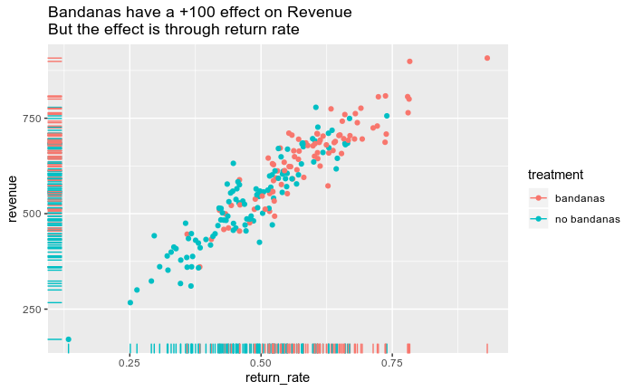

```r
# create a salon level dataset
set.seed(22)
n_salons <- 200
true_bandana_effect <- 100
noise <- 50
data_downstream <- tibble(salon_id = 1:n_salons) %>%
  mutate(
    # treatment (random in this case)
    gives_bandanas=rbinom(n_salons, 1,prob =  0.5),
    # downstream return rate increased by 10% if given bandanas
    return_rate=rnorm(n_salons, mean = 0.5, sd=0.1) + gives_bandanas*0.1 ,
    # outcome (influenced by return rate)
    #   note that bandanas only impact revenue through return rate
    revenue= 50 + true_bandana_effect*10*return_rate + rnorm(n_salons, sd=noise)
  )

# plot to visualize the relationships
data_downstream %>%
  mutate(treatment=ifelse(gives_bandanas==1, "bandanas", "no bandanas")) %>%
  ggplot(aes(return_rate, revenue, color=treatment)) +
  geom_point() +
  labs(title=glue("Bandanas have a +{true_bandana_effect} effect on Revenue \n",
                  "But the effect is through return rate\n")) +
  geom_rug()
```

Let’s see how running the regression works here:

```r
m_no_downstream <- lm(revenue ~ gives_bandanas, data=data_downstream)
summary(m_no_downstream)
```

```
Call:
lm(formula = revenue ~ gives_bandanas, data = data_downstream)

Residuals:
    Min      1Q  Median      3Q     Max
-357.66  -80.89   10.58   67.76  266.29

Coefficients:
               Estimate Std. Error t value Pr(>|t|)
(Intercept)      528.49      10.61   49.81  < 2e-16 ***
gives_bandanas   112.76      15.91    7.09 2.32e-11 ***
---
Signif. codes:  0 ‘***’ 0.001 ‘**’ 0.01 ‘*’ 0.05 ‘.’ 0.1 ‘ ’ 1

Residual standard error: 111.8 on 198 degrees of freedom
Multiple R-squared:  0.2025,    Adjusted R-squared:  0.1984
F-statistic: 50.26 on 1 and 198 DF,  p-value: 2.318e-11
```

We get an estimated effect that is very close to the true +100 effect when we don’t include the downstream variable.

```r
m_downstream <- lm(revenue ~ gives_bandanas + return_rate, data=data_downstream)
summary(m_downstream)
```

```
Call:
lm(formula = revenue ~ gives_bandanas + return_rate, data = data_downstream)

Residuals:
     Min       1Q   Median       3Q      Max
-124.599  -30.037   -0.053   31.601  131.088

Coefficients:
               Estimate Std. Error t value Pr(>|t|)
(Intercept)      61.536     15.645   3.933 0.000116 ***
gives_bandanas    2.470      7.459   0.331 0.740909
return_rate     982.025     31.588  31.088  < 2e-16 ***
---
Signif. codes:  0 ‘***’ 0.001 ‘**’ 0.01 ‘*’ 0.05 ‘.’ 0.1 ‘ ’ 1

Residual standard error: 46.11 on 197 degrees of freedom
Multiple R-squared:  0.865, Adjusted R-squared:  0.8636
F-statistic: 630.9 on 2 and 197 DF,  p-value: < 2.2e-16
```

Adding the return_rate to the regression eliminates the effect of giving bandanas. This is because holding return_rate fixed, giving bandanas doesn’t actually have an impact. But we are still interested in the effect of giving bandanas (even if through other variables) so we shouldnt control for downstream effects.

The other situation where we need to be careful about a distored association is when we add colliders to our regression.

### Don’t add Colliders

A collider is a variable that is influenced by both the treatment and the outcome. Adding a collider to a regression can distort the measured association between the treatment and outcome. For example, whether a salon as a storage closet or not. If the store gives bandanas, that likely need a clost to store it in and therefore giving bandanas influences whether or not there is a storage closet. Also, salons that have a lot of revenue likely see more customers, who leave things behind and thus they need a place to store lost and found items. Let’s consider an example where bandanas don’t have any impact on revenue, but where an association can be found if we accidentally control for this collider.

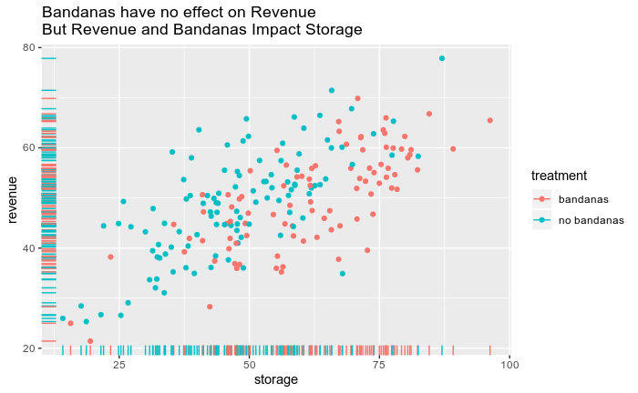

```r
set.seed(24)
true_bandana_effect <- 0
noise <- 10
n_salons <- 200
data_collider <- tibble(salon_id = 1:n_salons) %>%
  mutate(
    # treatment (random in this case)
    gives_bandanas=rbinom(n_salons, 1,prob =  0.5),
    # outcome (not impacted by treatment)
    revenue= 50 + rnorm(n_salons, sd=noise),
    # collider
    storage=revenue + 10*gives_bandanas + rnorm(n_salons, sd=noise)
  )
# plot to visualize the relationships
data_collider %>%
  mutate(treatment=ifelse(gives_bandanas==1, "bandanas", "no bandanas")) %>%
  ggplot(aes(storage, revenue, color=treatment)) +
  geom_point() +
  labs(title=glue("Bandanas have no effect on Revenue \n",
                  "But Revenue and Bandanas Impact Storage\n")) +
  geom_rug()
```

The regression works fine without a collider

```r
m_no_collider <- lm(revenue ~ gives_bandanas, data=data_collider)
summary(m_no_collider)
```

```
Call:
lm(formula = revenue ~ gives_bandanas, data = data_collider)

Residuals:
     Min       1Q   Median       3Q      Max
-28.3725  -6.6832   0.7519   6.6864  29.2365

Coefficients:
               Estimate Std. Error t value Pr(>|t|)
(Intercept)     48.6130     0.9819  49.510   <2e-16 ***
gives_bandanas   1.1989     1.4477   0.828    0.409
---
Signif. codes:  0 ‘***’ 0.001 ‘**’ 0.01 ‘*’ 0.05 ‘.’ 0.1 ‘ ’ 1

Residual standard error: 10.2 on 198 degrees of freedom
Multiple R-squared:  0.003452,  Adjusted R-squared:  -0.001581
F-statistic: 0.6858 on 1 and 198 DF,  p-value: 0.4086
```

We don’t measure any effect of giving bandanas then the collider is not included. This a good thing because in the data bandanas have no effect of revenue. But what happens when we add the collider?

```r
m_collider <- lm(revenue ~ gives_bandanas + storage, data=data_collider)
summary(m_collider)
```

[output not shown]

Now we measure a significant negative association between giving bandanas and revenue that does not actually exist. This is because of the “holding fixed” interpretation of a regression. For a given value of storage, revenue is negatively associated with giving bandanas.

Knowing whether or not to add covariates to accurately measure an effect is the most important, but it is also important to know when a covariate could increase the precision of your estimates.

## Covariates Impact of Precision

Covariates can increase the precision with which you estimate a particular coefficient if they are predictive of the outcome and not highly correlated with the variable whose coefficient you are trying to estimate.

This result may seem counterintuitive: isn’t adding covariates supposed to increase variance and therefore reduce precision? That’s true in terms of the predictions of the outcome the model produces, but not the estimates of the coefficients in the regression.

If we meet some standard assumptions of ordinary least squares (the relationship between our outcome and covariates is linear, the units are not impacting each other, there is no correlation between the treatment and other covariates that impact the outcome, homoskedasticty – see my stats stackexchange post for all assumptions and implications https://stats.stackexchange.com/questions/16381/what-is-a-complete-list-of-the-usual-assumptions-for-linear-regression/400600#400600) the variance of the OLS estimate of the coefficient on the treatment is:

$$Var(\hat{\beta}_{gives\_bandanas}) = \frac{\sigma^2}{(1-R^2_{gives\_bandanas})\sum_{salons}(gives\_bandanas_{salon} - \%gives\_bandanas)^2}$$

The sum in the denominator refers to how much variance there is in the application of our treatment (giving bandanas). This is not related to what covariates we add.

$\sigma^2$ is the error variance of the regression. The better we are at making predicitions of the outcome with the regression, the lower this value will be. Therefore, if we add covariates that are highly predictive of the outcome $\sigma^2$ will decrease.

However, $R^2_{gives\_bandanas}$ represents the R^2 if we ran a regression with gives_bandanas as the outcome and all the other covariates as explanatory variables. This means that if we add covariates that are highly correlated with the treatment (gives_bandanas) our estimate of the coefficient on the treatment will have a higher variance. This speaks to the fact that you should not add variables that are highly correlated with the treatment, unless they are confounders that are also highly correlated to the outcome.

Let’s illustrate. Suppose giving bandanas is not correlated with the number of dogs where the salon is, but salon revenue is (adding number of dogs to the regression will increase precision). Also, suppose that whether or not the salon gets ads from local bandana suppliers influences whether or not the salon gives bandanas, but does not affect the salons revenue directly (adding whether the salon received ads will reduce precision).

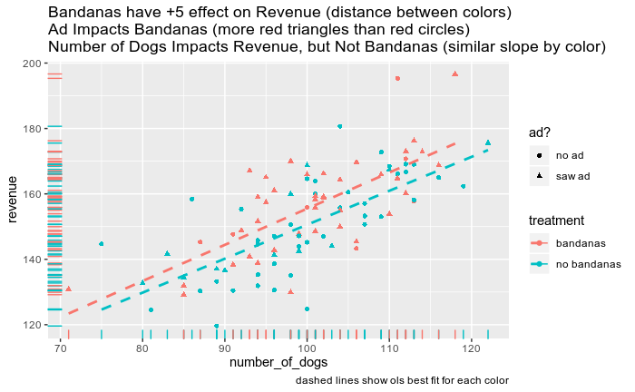

```r
set.seed(20)
true_bandana_effect <- 5
noise <- 10
n_salons <- 101
data_precision <- tibble(salon_id = 1:n_salons) %>%
  mutate(
    # random number of dogs
    number_of_dogs=round(rnorm(n_salons, mean=100, sd=10)),
    # random chance of seeing ad
    saw_bandanas_ad=rbinom(n_salons, 1,prob =  0.5),
    # treatment more likely when saw ad, not impacted by number of dogs
    gives_bandanas=rbinom(n_salons, 1,prob =  ifelse(saw_bandanas_ad==1, .8, .2)),
    # outcome (not impacted by ad, but impacted by number of dogs)
    revenue= 50 + rnorm(n_salons, sd=noise) + true_bandana_effect*gives_bandanas + number_of_dogs
  )
# plot to visualize the relationships
data_precision %>%
  mutate(
    treatment=ifelse(gives_bandanas==1, "bandanas", "no bandanas"),
    `ad?`=ifelse(saw_bandanas_ad==1,"saw ad", "no ad")
         ) %>%
  ggplot(aes(number_of_dogs, revenue, color=treatment)) +
  geom_point(aes( shape=`ad?`)) +
  geom_smooth(method='lm',se=F,linetype='dashed') +
  labs(title=glue("Bandanas have +{true_bandana_effect} effect on Revenue (distance between colors)\n",
                  "Ad Impacts Bandanas (more red triangles than red circles)\n",
                  "Number of Dogs Impacts Revenue, but Not Bandanas (similar slope by color)"),
       caption="dashed lines show ols best fit for each color") +
  geom_rug()
```

Let’s start with a regression using just treatment.

```r
m_precision_just_treatment <- lm(
  revenue ~ gives_bandanas, data=data_precision
)
summary(m_precision_just_treatment)
```

```
Call:
lm(formula = revenue ~ gives_bandanas, data = data_precision)

Residuals:
    Min      1Q  Median      3Q     Max
-30.283 -11.274   0.818  10.166  40.101

Coefficients:
               Estimate Std. Error t value Pr(>|t|)
(Intercept)     149.884      2.050  73.113   <2e-16 ***
gives_bandanas    6.683      2.974   2.247   0.0268 *
---
Signif. codes:  0 ‘***’ 0.001 ‘**’ 0.01 ‘*’ 0.05 ‘.’ 0.1 ‘ ’ 1

Residual standard error: 14.92 on 99 degrees of freedom
Multiple R-squared:  0.04854,   Adjusted R-squared:  0.03893
F-statistic:  5.05 on 1 and 99 DF,  p-value: 0.02684
```

We measure an accurate effect fairly close to the ture impact of 5.

Now let’s add the predictive covariate.

```r
summary(m_precision_w_predictor)
```

```
Call:
lm(formula = revenue ~ gives_bandanas + number_of_dogs, data = data_precision)

Residuals:
     Min       1Q   Median       3Q      Max
-25.7912  -7.2066   0.4124   6.1852  28.0585

Coefficients:
               Estimate Std. Error t value Pr(>|t|)
(Intercept)     43.8543    10.7799   4.068 9.59e-05 ***
gives_bandanas   4.9329     2.1179   2.329   0.0219 *
number_of_dogs   1.0673     0.1075   9.927  < 2e-16 ***
---
Signif. codes:  0 ‘***’ 0.001 ‘**’ 0.01 ‘*’ 0.05 ‘.’ 0.1 ‘ ’ 1

Residual standard error: 10.59 on 98 degrees of freedom
Multiple R-squared:  0.5256,    Adjusted R-squared:  0.5159
F-statistic: 54.28 on 2 and 98 DF,  p-value: < 2.2e-16
```

Now we measure an effect much more precisely! The coefficient on gives_bandanas is much closer to 5 with a lower standard error.

But what if we had added a non-predictor that was correlated with treatment instead?

```r
summary(m_precision_w_non_predictor)
```

```
Call:
lm(formula = revenue ~ gives_bandanas + saw_bandanas_ad, data = data_precision)

Residuals:
    Min      1Q  Median      3Q     Max
-30.494 -11.486   0.543  10.394  40.257

Coefficients:
                Estimate Std. Error t value Pr(>|t|)
(Intercept)     150.0956     2.2284  67.357   <2e-16 ***
gives_bandanas    7.2503     3.7578   1.929   0.0566 .
saw_bandanas_ad  -0.9349     3.7548  -0.249   0.8039
---
Signif. codes:  0 ‘***’ 0.001 ‘**’ 0.01 ‘*’ 0.05 ‘.’ 0.1 ‘ ’ 1

Residual standard error: 15 on 98 degrees of freedom
Multiple R-squared:  0.04914,   Adjusted R-squared:  0.02973
F-statistic: 2.532 on 2 and 98 DF,  p-value: 0.08467
```

Now we have less precision and are further away from the true effect of 5.

# Summary